# Dynamics and Control - RMan project 2

Mathias Dam - ist1117164 Timothée Lawani - ist1119605 Martin Chodos Figueiredo - ist1119554

This notebook presents answers to the questions in the second part of the RMan project. The project was implemented using Python code. This report is an export of the jupyter notebook file that the group worked in to provide answers to all questions. The group decided to submit this instead of a standard pdf report, as it contains detailed answers to all questions and all the code used in a single file, making evaluating easier for the professor.

In addition to this pdf, a zipped folder with all the code done for the project is included in the submission, including the jupyter notebook that this pdf is made from. All the libraries used are stored in a virtual enviorment inside the folder, so the professor will be able to run the jupyter notebook, verify the groups code and get interactive 3d-animations of the robot arm movement without installing any libraries. Two video files are also submitted, containing screen recordings of the animations of the robot arm following the path from question 5 using the controllers implemented in question 3 and 4. This lets the professor see the animations without running the code.

## Library Imports and Variable Definitions

```python
#Imports
import numpy as np
from kinematics_functions import *
from scipy.integrate import solve_ivp
from tqdm import tqdm
import matplotlib.pyplot as plt
from scipy.interpolate import CubicSpline, interp1d
import plotly.graph_objects as go





# Spesific problem parameters

# d values, consisten with following answer to question 1, not consistent with estimates we did for kinematics part of poject
d_1 = 0.34
d_3 = 0.40    # upper arm  (shoulder → elbow)
d_5 = 0.40    # forearm    (elbow → wrist)
d_7 = 0.126   # flange/tool (wrist → flange)

# DH_table
def DH(q):
    return np.array([
        # d,    theta,  a,  alpha
        [d_1,   q[0],   0,  np.pi/2 ],
        [0,     q[1],   0, -np.pi/2 ],
        [d_3,   q[2],   0, -np.pi/2 ],
        [0,     q[3],   0,  np.pi/2 ],
        [d_5,   q[4],   0,  np.pi/2 ],
        [0,     q[5],   0, -np.pi/2 ],
        [d_7,   q[6],   0,  0       ],
    ])

# KUKA LBR Med 7 R800 continuous joint torque limits [Nm]
TAU_LIMITS = np.array([176, 176, 110, 110, 110, 40, 40], dtype=float)
```

# Question 1 - Approximate Link Inertias

## Method

Each of the 7 links is approximated as a **single solid cylinder** sized to the arm's outer envelope. Lengths come from the published iiwa kinematic offsets (0.34 / 0.40 / 0.40 / 0.126 m for the limb segments; the shoulder, elbow and wrist joint-pairs are co-located, so their housings are modelled as short cylinders). Radii are read off the photograph, tapering from ~65 mm at the base to ~35 mm at the flange.

A real cobot link is a hollow aluminium shell containing a motor, gearbox and torque sensor. Instead of modelling those internals, the solid cylinder is given a single **effective density** ρ = 1565 kg/m³ (~58% of solid aluminium). That value is calibrated so the seven cylinder masses sum to the catalogue robot mass of ~24 kg. Using the larger cylinders for the proximal links automatically puts more mass near the base, as in the real arm.

Link frame *i* sits at joint *i* with its **z-axis along the joint axis**. Since each cylinder is axisymmetric about that axis, every COM lies on z and each inertia tensor is **diagonal** in the link frame (products of inertia ≈ 0).

## Formulas

For a cylinder of mass m = ρ·πr²L, length L along its axis, radius r:

- axial inertia: **Izz = ½ m r²**
- transverse inertia: **Ixx = Iyy = (1/12) m (3r² + L²)**

both taken about the COM, located at the cylinder's mid-length.

## Per-link results

| Link | Calculation (L, r → m; Izz; Ixx=Iyy) |
| --- | --- |
| 1 base/shoulder | L=0.34, r=0.065 → m=7.06 kg; Izz=0.0149; Ixx=Iyy=0.0755; com_z=0.150 |
| 2 shoulder pitch | L=0.18, r=0.060 → m=3.19 kg; Izz=0.00573; Ixx=Iyy=0.0115; com_z=0 |
| 3 upper arm | L=0.40, r=0.055 → m=5.95 kg; Izz=0.00900; Ixx=Iyy=0.0838; com_z=0.180 |
| 4 elbow pitch | L=0.16, r=0.050 → m=1.97 kg; Izz=0.00246; Ixx=Iyy=0.00542; com_z=0 |
| 5 forearm | L=0.40, r=0.045 → m=3.98 kg; Izz=0.00403; Ixx=Iyy=0.0551; com_z=0.170 |
| 6 wrist pitch | L=0.14, r=0.040 → m=1.10 kg; Izz=0.000881; Ixx=Iyy=0.00224; com_z=0 |
| 7 flange/tool | L=0.126, r=0.035 → m=0.76 kg; Izz=0.000465; Ixx=Iyy=0.00124; com_z=0.050 |

Units: kg, m, kg·m². Total mass = 24.0 kg.

## Python representation

```python
# KUKA LBR Med 7 R800 — approximate inertial parameters of the 7 links.
# Each link modelled as a solid cylinder; effective density 1565 kg/m^3
# calibrated so masses sum to ~24 kg. Inertia about COM, in link frame.
# Row = [mass, cx, cy, cz, Ixx, Iyy, Izz, Ixy, Ixz, Iyz]   (units: kg, m, kg*m^2)
LINKS = np.array([
    [7.061, 0, 0, 0.150, 7.5475e-2, 7.5475e-2, 1.4916e-2, 0, 0, 0],
    [3.185, 0, 0, 0.000, 1.1466e-2, 1.1466e-2, 5.7330e-3, 0, 0, 0],
    [5.947, 0, 0, 0.180, 8.3796e-2, 8.3796e-2, 8.9954e-3, 0, 0, 0],
    [1.966, 0, 0, 0.000, 5.4231e-3, 5.4231e-3, 2.4576e-3, 0, 0, 0],
    [3.981, 0, 0, 0.170, 5.5099e-2, 5.5099e-2, 4.0310e-3, 0, 0, 0],
    [1.101, 0, 0, 0.000, 2.2387e-3, 2.2387e-3, 8.8080e-4, 0, 0, 0],
    [0.759, 0, 0, 0.050, 1.2360e-3, 1.2360e-3, 4.6468e-4, 0, 0, 0],
])

mass = LINKS[:, 0]
com  = LINKS[:, 1:4]
# inertia tensor per link (diagonal here, off-diagonals ~0):
inertia = np.array([np.diag(r[4:7]) for r in LINKS])
```

# Question 2 - Making the model

We need to make a model. This basically means that we need to make some sort of code where we can test out different functions for calculating the joint torque vector, then we need to be able to calculate the resulting motion of the whole robot arm and plot it and evaluate it.

## Framework

Fundamentally, this model will be based on a function that takes in the current state, current timestep, and some sort of function for that returns the torque vector, and then returns the velocity and acelleration, like this template function:

```
def dynamics(t, q, q_dot, tau_func):
    tau = tau_func(t, q, q_dot)
    q_ddot = forward_dynamics(q, q_dot, tau)
    return q_dot, q_ddot
```

This function can then be solved with an ODE solver for example from scipy to get the full behaviour of the robot arm. Saving an array with the states at the different timesteps will allow us to easily plot the movement of the robot arm.

## Implementation of the forward_dynamics function

Now that we have a plan for the framework, let's start diving into the requirements for implementing the function above. The tau function will be based on what control algorithm is used, so this will be dealt with in question 3 and 4, for now we can just ignore it. The forward_dynamics function we need to implement now. This function will be based on the equation: $$ \tau = B(q)\ddot{q} + C(q, \dot{q})\dot{q} + g(q) $$ This equation can easily be rewritten so that $\ddot{q}$ stands alone, giving us exactly what we need for the forward_dynamics function. However, we need to find the expressions for $M(q)$, $C(q, \dot{q})$ and $g(q)$. LEt's find these terms one by one.

### Inertia matrix

The mass and inertia matrix $B(q)$ can be found either by using a Lagrangian approach, or by using the newton-euler method. We will now find it using the newton-euler method because it is slightly more efficient, and because it is harder to implement so we will learn more by implementing it.

Row n in B(q) represents all the torques required to accelerate joint n. When we use the Newton-Euler approach, we find each of these columns by doing a forward and backwards pass. We start by assuming that all velocities and gravity are zero. Then, in the forwards pass, we calculate how each link will move when we have an acceleration on joint n. To calculate this, we use formulas based on Newtons equations. For a revolute joint, the forward Newton--Euler pass can be written as:

$$\boldsymbol{\omega}_i={}^{i}\!R_{i-1}\boldsymbol{\omega}_{i-1}+\mathbf{z}_i \dot q_i$$

$$\dot{\boldsymbol{\omega}}_i={}^{i}\!R_{i-1}\dot{\boldsymbol{\omega}}_{i-1}+\mathbf{z}_i \ddot q_i+\left({}^{i}\!R_{i-1}\boldsymbol{\omega}_{i-1}\right)\times\left(\mathbf{z}_i \dot q_i\right)$$

$$\mathbf{a}_i={}^{i}\!R_{i-1}\left(\mathbf{a}_{i-1}+\dot{\boldsymbol{\omega}}_{i-1} \times \mathbf{p}_i+\boldsymbol{\omega}_{i-1}\times\left(\boldsymbol{\omega}_{i-1} \times \mathbf{p}_i\right)\right)$$

$$\mathbf{a}_{c_i}=\mathbf{a}_i+\dot{\boldsymbol{\omega}}_i \times \mathbf{r}_{c_i}+\boldsymbol{\omega}_i\times\left(\boldsymbol{\omega}_i \times \mathbf{r}_{c_i}\right)$$

Below is an implemented frunction B(q) that is based on this method.

```python
def B(q, DH_func=DH):
    n = len(q)
    DH_table = DH_func(q)
    z = np.array([0.0, 0.0, 1.0])

    T_list = [T_from_DH_row(row) for row in DH_table]
    B_mat = np.zeros((n, n))

    for col in range(n):
        q_ddot = np.zeros(n)
        q_ddot[col] = 1.0

        alpha = np.zeros((n, 3))
        a     = np.zeros((n, 3))
        a_c   = np.zeros((n, 3))

        for i in range(n):
            R     = T_list[i][:3, :3].T        # ^i R_{i-1}
            p     = T_list[i][:3, 3]            # origin of frame i in frame i-1
            z_i   = T_list[i][:3, :3].T @ z    # joint i axis in frame i (= z_{i-1} rotated)

            alpha_prev = alpha[i-1] if i > 0 else np.zeros(3)
            a_prev     = a[i-1]     if i > 0 else np.zeros(3)

            alpha[i] = R @ alpha_prev + z_i * q_ddot[i]
            a[i]     = R @ (a_prev + np.cross(alpha_prev, p))
            a_c[i]   = a[i] + np.cross(alpha[i], com[i])

        f_next = np.zeros(3)
        n_next = np.zeros(3)

        for i in range(n - 1, -1, -1):
            F_i = mass[i] * a_c[i]
            N_i = inertia[i] @ alpha[i]

            if i < n - 1:
                R_next      = T_list[i+1][:3, :3]
                p_next      = T_list[i+1][:3, 3]
                f_from_next = R_next @ f_next
                n_from_next = R_next @ n_next
            else:
                f_from_next = np.zeros(3)
                n_from_next = np.zeros(3)
                p_next      = np.zeros(3)

            f_i = f_from_next + F_i
            n_i = N_i + np.cross(com[i], F_i) + np.cross(p_next, f_from_next) + n_from_next

            # Rotate n_i to frame i-1; joint i's axis is z_{i-1} = [0,0,1] there
            B_mat[i, col] = z @ (T_list[i][:3, :3] @ n_i)

            f_next = f_i
            n_next = n_i

    return B_mat

q_test = np.zeros(7)
B_test = B(q_test)
print("B symmetric:", np.allclose(B_test, B_test.T, atol=1e-10))
print("Eigenvalues (all positive?):", np.linalg.eigvalsh(B_test).round(4))
```

```
B symmetric: True
Eigenvalues (all positive?): [5.000e-04 1.570e-02 3.970e-02 1.109e-01 1.639e-01 1.157e+00 6.205e+00]
```

### Coriolis vector

Next, we need to find the coriolis term $C(q, \dot{q})\dot{q}$. To find this, we can actually use the Newton-Euler method again. We do a very similar implementation as the one above, but instead of setting the gravity and velocity to zero, we set the gravity and *acceleration* to zero.

We use the same formulas that we used to find B(q). An implementation of a C_vector(q, q_dot) function using this approach can be found below.

```python
def C_vector(q, q_dot, DH_func=DH):
    """Returns C(q, q_dot) @ q_dot — the full Coriolis + centripetal torque vector."""
    n = len(q)
    DH_table = DH_func(q)
    z = np.array([0.0, 0.0, 1.0])

    T_list = [T_from_DH_row(row) for row in DH_table]

    omega = np.zeros((n, 3))
    alpha = np.zeros((n, 3))
    a     = np.zeros((n, 3))
    a_c   = np.zeros((n, 3))

    for i in range(n):
        R   = T_list[i][:3, :3].T        # ^i R_{i-1}
        p   = T_list[i][:3, 3]
        z_i = T_list[i][:3, :3].T @ z   # joint i axis in frame i

        omega_prev      = omega[i-1] if i > 0 else np.zeros(3)
        alpha_prev      = alpha[i-1] if i > 0 else np.zeros(3)
        a_prev          = a[i-1]     if i > 0 else np.zeros(3)
        omega_prev_in_i = R @ omega_prev

        omega[i] = omega_prev_in_i + z_i * q_dot[i]
        alpha[i] = R @ alpha_prev + np.cross(omega_prev_in_i, z_i * q_dot[i])
        a[i]     = R @ (a_prev + np.cross(alpha_prev, p) + np.cross(omega_prev, np.cross(omega_prev, p)))
        a_c[i]   = a[i] + np.cross(alpha[i], com[i]) + np.cross(omega[i], np.cross(omega[i], com[i]))

    c_vec  = np.zeros(n)
    f_next = np.zeros(3)
    n_next = np.zeros(3)

    for i in range(n - 1, -1, -1):
        F_i = mass[i] * a_c[i]
        N_i = inertia[i] @ alpha[i] + np.cross(omega[i], inertia[i] @ omega[i])

        if i < n - 1:
            R_next      = T_list[i+1][:3, :3]
            p_next      = T_list[i+1][:3, 3]
            f_from_next = R_next @ f_next
            n_from_next = R_next @ n_next
        else:
            f_from_next = np.zeros(3)
            n_from_next = np.zeros(3)
            p_next      = np.zeros(3)

        f_i = f_from_next + F_i
        n_i = N_i + np.cross(com[i], F_i) + np.cross(p_next, f_from_next) + n_from_next

        c_vec[i] = z @ (T_list[i][:3, :3] @ n_i)

        f_next = f_i
        n_next = n_i

    return c_vec

print("C_vector(q, 0):", C_vector(np.array([0.1, 0.2, 0.3, 0.1, 0.2, 0.1, 0.0]), np.zeros(7)).round(10))
```

```
C_vector(q, 0): [0. 0. 0. 0. 0. 0. 0.]
```

### Gravity vector

The last component needed to finish our masterplan from above is the gravity vector. This vector simply says what torque acts on each joint due to gravity pulling the robot arm down.

For the gravity vector we actually still use the Newton-Euler approach, just that now we set both velocity and acceleration to zero, and only include the gravity term in the input. This is implemented below.

```python
def g(q, DH_func=DH):
    """Returns the gravity torque vector g(q)."""
    n = len(q)
    DH_table = DH_func(q)
    z    = np.array([0.0, 0.0, 1.0])
    g0   = np.array([0.0, 0.0, 9.81])   # fictitious upward base acceleration (= -gravity)

    T_list = [T_from_DH_row(row) for row in DH_table]

    # --- Forward pass ---
    # omega=0, alpha=0 everywhere (q_dot=q_ddot=0); only gravity propagates
    a   = np.zeros((n, 3))   # linear acceleration of frame i origin, in frame i
    a_c = np.zeros((n, 3))   # linear acceleration of link i COM, in frame i

    for i in range(n):
        R = T_list[i][:3, :3].T   # ^i R_{i-1}
        a_prev = a[i-1] if i > 0 else g0

        a[i]   = R @ a_prev   # rotate gravity into frame i (no cross terms since omega=alpha=0)
        a_c[i] = a[i]         # COM acc = frame acc (cross terms vanish)

    # --- Backward pass ---
    grav = np.zeros(n)
    f_next = np.zeros(3)
    n_next = np.zeros(3)

    for i in range(n - 1, -1, -1):
        F_i = mass[i] * a_c[i]   # gravity force on link i (alpha=omega=0, so N_i=0)

        if i < n - 1:
            R_next = T_list[i+1][:3, :3]  # ^i R_{i+1}
            p_next = T_list[i+1][:3, 3]
            f_from_next = R_next @ f_next
            n_from_next = R_next @ n_next
        else:
            f_from_next = np.zeros(3)
            n_from_next = np.zeros(3)
            p_next      = np.zeros(3)

        f_i = f_from_next + F_i
        n_i = np.cross(com[i], F_i) + np.cross(p_next, f_from_next) + n_from_next

        # Project n_i back to frame i-1 first: joint i's axis is z of frame i-1
        grav[i] = z @ (T_list[i][:3, :3] @ n_i)

        f_next = f_i
        n_next = n_i

    return grav

print("g(q=0):", g(np.zeros(7)).round(4))
```

```
g(q=0): [0. 0. 0. 0. 0. 0. 0.]
```

### Full forward dynamics function

The three terms that we have now calculated can all be combined to get the full forward dynamics function by using the equation: $$ \ddot{q}= B(q)^{-1} (\Tau - C(q, \dot{q})\dot{q} - g(q)) $$ Below is an implementation of the full forward dynamics function.

```python
def forward_dynamics(q, q_dot, tau, DH_func=DH):
    """Returns q_ddot given q, q_dot, and tau."""
    B_mat = B(q, DH_func)
    C_vec = C_vector(q, q_dot, DH_func)
    g_vec = g(q, DH_func)

    # Solve for q_ddot: B @ q_ddot + C_vec + g_vec = tau
    q_ddot = np.linalg.solve(B_mat, tau - C_vec - g_vec)
    return q_ddot
```

### Full dynamic simulation function

Now that we have implemented the forward dynamics function, we are ready to build the full dynamic model. First, we build the single timestep dynamic evaluation function:

```python
def dynamics(t, q, q_dot, tau_func, desired_state_func):
    tau = tau_func(t, q, q_dot, desired_state_func)
    tau = np.clip(tau, -TAU_LIMITS, TAU_LIMITS)
    q_ddot = forward_dynamics(q, q_dot, tau)
    return q_dot, q_ddot
```

The output values from the tau function are clipped. This is to simulate that the actuators in the robot-arm have a maximum torque. The values are estimates on how much torque each joint in the robotic arm is able to produce.

Then, the full solution is obtained by solving this function with an ODE solver:

```python
def simulate(tau_func, desired_state_func, q_0, q_dot_0, t_span=(0, 5.0), dt=0.01, rtol=1e-6, atol=1e-8):
    n = len(q_0)
    y0 = np.concatenate([q_0, q_dot_0])
    t_eval = np.arange(t_span[0], t_span[1], dt)

    with tqdm(total=t_span[1] - t_span[0], unit='s', desc='Simulating') as pbar:
        last_t = [t_span[0]]

        def ode(t, y):
            pbar.update(t - last_t[0])
            last_t[0] = t
            q, q_dot = y[:n], y[n:]
            _, q_ddot = dynamics(t, q, q_dot, tau_func, desired_state_func)
            return np.concatenate([q_dot, q_ddot])

        sol = solve_ivp(ode, t_span, y0, method='RK45', t_eval=t_eval, rtol=rtol, atol=atol)

    t     = sol.t
    q     = sol.y[:n].T
    q_dot = sol.y[n:].T
    return t, q, q_dot
```

### Plotting

In order to get any useful information from the simulation, we need to be able to plot the results. Below are two functions for doing this, both take the output from the simulate function as input.

The first is more of a visual plot, it creates a moving 3d visual of the movement of the robot. Useful for seeing the movement and seeing if it looks correct. It is implemented using the library plotly.

The second one is a simple 2d plot showing the euclidean distance between the coordinates of the end effector and the desired end effector coordinates as a function of time, in addition to printing values like average and max error. This one is more useful for comparing the performance of different control algorithms. It is implemented using matplotlib.

```python
# ── KUKA LBR Med 7 approximate visual dimensions ─────────────────────────────
_LW = np.array([0.110, 0.090, 0.085, 0.075, 0.070, 0.060, 0.055])
_LH = np.array([0.085, 0.075, 0.070, 0.065, 0.060, 0.055, 0.050])
_JR = np.array([0.068, 0.060, 0.057, 0.052, 0.047, 0.042, 0.038])
_JH = 0.065

# ── rotation that maps [0,0,1] → d_hat ───────────────────────────────────────
def _rot_z_to(d_hat):
    z = np.array([0., 0., 1.])
    v = np.cross(z, d_hat); s = np.linalg.norm(v); c = float(z @ d_hat)
    if s < 1e-9:
        return np.eye(3) if c > 0 else np.diag([1., -1., -1.])
    vx = np.array([[0, -v[2], v[1]], [v[2], 0, -v[0]], [-v[1], v[0], 0]])
    return np.eye(3) + vx + vx @ vx * ((1 - c) / s**2)

# ── canonical box: cross-section in xy, length along z in [0, 1] ─────────────
_BV = np.array([
    [-.5,-.5,0],[.5,-.5,0],[.5,.5,0],[-.5,.5,0],
    [-.5,-.5,1],[.5,-.5,1],[.5,.5,1],[-.5,.5,1]], dtype=np.float32)
_BF = np.array([
    [0,1,2],[0,2,3], [4,6,5],[4,7,6],
    [0,4,5],[0,5,1], [2,6,7],[2,7,3],
    [0,3,7],[0,7,4], [1,5,6],[1,6,2]], dtype=np.int32)

def _box_verts(p0, p1, w, h):
    d = p1 - p0; L = np.linalg.norm(d)
    R = _rot_z_to(d / max(L, 1e-6))
    return ((R @ (_BV * [w, h, max(L, 1e-6)]).T).T + p0).astype(np.float32)

# ── canonical cylinder: radius 1, height 1, centred at origin ────────────────
_NC = 22
_th = np.linspace(0, 2 * np.pi, _NC, endpoint=False)
_CV = np.vstack([
    np.c_[np.cos(_th), np.sin(_th), np.full(_NC, -.5)],
    np.c_[np.cos(_th), np.sin(_th), np.full(_NC, +.5)],
    [[0, 0, -.5], [0, 0, .5]]]).astype(np.float32)
_cf = []
for _i in range(_NC):
    _j = (_i + 1) % _NC
    _cf += [[_i, _j, _NC+_j], [_i, _NC+_j, _NC+_i],
            [2*_NC, _j, _i], [2*_NC+1, _NC+_i, _NC+_j]]
_CF = np.array(_cf, dtype=np.int32)

def _cyl_verts(center, axis, r, h):
    a = np.asarray(axis, float); n = np.linalg.norm(a)
    a = a / n if n > 1e-9 else np.array([0., 0., 1.])
    R = _rot_z_to(a)
    return ((R @ (_CV * [r, r, h]).T).T + np.asarray(center, float)).astype(np.float32)

# ── pre-compute combined face arrays (topology is constant) ──────────────────
def _combined_faces(n):
    lf = np.vstack([_BF + i * len(_BV) for i in range(n)])
    jf = np.vstack([_CF + i * len(_CV) for i in range(n)])
    return lf, jf

def _get_frame_verts(qi, DH_func):
    """Compute combined link and joint vertex arrays for one configuration."""
    tbl = DH_func(qi)
    n   = len(qi)
    T   = [np.eye(4)] + [n_T_n_from_DH_table(tbl, 0, k+1) for k in range(n)]
    lvs = [_box_verts(T[k][:3,3], T[k+1][:3,3], _LW[k], _LH[k]) for k in range(n)]
    jvs = [_cyl_verts(T[k+1][:3,3], T[k+1][:3,2], _JR[k], _JH)  for k in range(n)]
    return np.vstack(lvs), np.vstack(jvs)

# ── 2D tracking error plot ────────────────────────────────────────────────────
def plot_tracking_error(t, q, desired_state_func, DH_func=DH):
    n = q.shape[1]

    # Forward kinematics for simulated and desired trajectories
    p_sim = np.array([n_T_n_from_DH_table(DH_func(q[i]), 0, n)[:3, 3] for i in range(len(t))])
    p_des = np.array([n_T_n_from_DH_table(DH_func(np.asarray(desired_state_func(t[i])[0])), 0, n)[:3, 3]
                      for i in range(len(t))])

    errors = np.linalg.norm(p_sim - p_des, axis=1)

    print("End-effector position error:")
    print(f"  Final : {errors[-1]*1e3:.2f} mm")
    print(f"  Mean  : {errors.mean()*1e3:.2f} mm")
    print(f"  Max   : {errors.max()*1e3:.2f} mm")

    fig, axes = plt.subplots(2, 2, figsize=(12, 7), sharex=True)
    coords   = ['x', 'y', 'z']
    colors   = ['#4a90d9', '#e07b54', '#5ab87a']

    for k, (ax, coord, color) in enumerate(zip(axes.flat, coords, colors)):
        ax.plot(t, p_des[:, k] * 1e3, '--', color='#888888', linewidth=1.4, label='desired')
        ax.plot(t, p_sim[:, k] * 1e3,       color=color,    linewidth=1.5, label='simulated')
        ax.set_ylabel(f'{coord}  [mm]')
        ax.set_title(f'End-effector {coord} coordinate')
        ax.legend(fontsize=9); ax.grid(alpha=0.3)

    ax_err = axes[1, 1]
    ax_err.plot(t, errors * 1e3, color='steelblue', linewidth=1.5)
    ax_err.set_ylabel('Error  [mm]')
    ax_err.set_title('Euclidean distance error')
    ax_err.grid(alpha=0.3)

    for ax in axes[1]:
        ax.set_xlabel('Time  [s]')

    plt.tight_layout()
    plt.show()

# ── 3D Plotly animation ───────────────────────────────────────────────────────
def animate_robot(t, q, DH_func=DH, max_frames=300, speed=1.0):
    """
    Render a smooth inline Plotly 3-D animation in Jupyter.

    All frames are pre-computed; playback is entirely browser-side (WebGL)
    — the Python kernel is not involved during animation.

    Parameters
    ----------
    t          : (T,)   time array from simulate()
    q          : (T, n) joint-position array
    max_frames : int    cap on stored frames (subsample if len(t) > max_frames)
    speed      : float  playback speed multiplier
    """
    n = q.shape[1]
    if len(t) > max_frames:
        idx  = np.round(np.linspace(0, len(t)-1, max_frames)).astype(int)
        t, q = t[idx], q[idx]

    lf, jf = _combined_faces(n)
    dt_s    = float(t[1] - t[0]) if len(t) > 1 else 0.01
    frame_ms = max(16, int(1000 * dt_s / speed))

    # Pre-compute every frame's vertices (fast numpy ops)
    frames_lv, frames_jv = zip(*[_get_frame_verts(q[i], DH_func) for i in range(len(t))])

    # Static base disk
    base_v  = _cyl_verts([0, 0, -0.05], [0, 0, 1], 0.13, 0.10)
    base_cf = _CF.copy()

    _light = dict(ambient=0.45, diffuse=0.9, specular=0.6, roughness=0.25, fresnel=0.15)
    _lpos  = dict(x=200, y=300, z=500)

    def _traces(i):
        lv, jv = frames_lv[i], frames_jv[i]
        return [
            go.Mesh3d(x=base_v[:,0], y=base_v[:,1], z=base_v[:,2],
                      i=base_cf[:,0], j=base_cf[:,1], k=base_cf[:,2],
                      color='#484858', flatshading=False,
                      lighting=dict(ambient=0.6, diffuse=0.8), showscale=False),
            go.Mesh3d(x=lv[:,0], y=lv[:,1], z=lv[:,2],
                      i=lf[:,0], j=lf[:,1], k=lf[:,2],
                      color='#AFC8E8', flatshading=False,
                      lighting=_light, lightposition=_lpos, showscale=False),
            go.Mesh3d(x=jv[:,0], y=jv[:,1], z=jv[:,2],
                      i=jf[:,0], j=jf[:,1], k=jf[:,2],
                      color='#585868', flatshading=False,
                      lighting=_light, lightposition=_lpos, showscale=False),
        ]

    plotly_frames = [go.Frame(data=_traces(i), name=str(i)) for i in range(len(t))]

    slider_steps = [
        dict(args=[[str(i)], dict(mode='immediate', frame=dict(duration=0, redraw=True))],
             method='animate', label=f'{t[i]:.2f}')
        for i in range(len(t))
    ]

    fig = go.Figure(
        data=_traces(0),
        frames=plotly_frames,
        layout=go.Layout(
            title=dict(text='Robot Arm — drag to rotate · scroll to zoom',
                       font=dict(color='#99aacc', size=13)),
            scene=dict(
                xaxis=dict(range=[-1.3, 1.3], showticklabels=False,
                           showgrid=False, zeroline=False, title=''),
                yaxis=dict(range=[-1.3, 1.3], showticklabels=False,
                           showgrid=False, zeroline=False, title=''),
                zaxis=dict(range=[-0.15, 1.55], showticklabels=False,
                           showgrid=False, zeroline=False, title=''),
                aspectmode='manual',
                aspectratio=dict(x=1, y=1, z=1.1),
                bgcolor='#16162a',
                camera=dict(eye=dict(x=1.4, y=1.4, z=0.9)),
            ),
            paper_bgcolor='#16162a',
            font=dict(color='white'),
            margin=dict(l=0, r=0, t=45, b=70),
            height=640,
            updatemenus=[dict(
                type='buttons', showactive=False,
                y=0.02, x=0.02, xanchor='left', yanchor='bottom',
                buttons=[
                    dict(label='▶  Play', method='animate',
                         args=[None, dict(frame=dict(duration=frame_ms, redraw=True),
                                          fromcurrent=True, mode='immediate')]),
                    dict(label='⏸  Pause', method='animate',
                         args=[[None], dict(frame=dict(duration=0), mode='immediate')]),
                ],
            )],
            sliders=[dict(
                active=0, steps=slider_steps,
                x=0.02, len=0.96, y=0.0,
                currentvalue=dict(prefix='t = ', suffix=' s', visible=True,
                                  xanchor='center', font=dict(color='white', size=12)),
                transition=dict(duration=0),
                bgcolor='#282840', bordercolor='#4a4a70',
                font=dict(color='#aaaacc', size=10),
            )],
        )
    )

    fig.show()
```

### Validation

Before moving on to the next question, we should validate that the model we have implemented works. To do this, we will implement a super simple PD-based tau function. This will not be properly tuned, and is therefore unlikely to give good results, but it is just a super simple implementation to see that the model can run and plot without issues, and that the robot arm behaves in a somewhat realistic way.

```python
def test_PID(t, q, q_dot, desired_state_func):
    Kp = np.diag([100, 100, 100, 50, 50, 50, 20])
    Kd = np.diag([50, 50, 50, 20, 20, 10, 5])
    q_d, q_dot_d, _ = desired_state_func(t)
    tau = Kp @ (np.asarray(q_d) - q) + Kd @ (np.asarray(q_dot_d) - q_dot)
    return tau
```

With this simple PD controller implemented, we can run the simulation with 0 on all join angles as the initial position and see how it behaves, plotting the results.

```
End-effector position error:
  Final : 502.38 mm
  Mean  : 477.91 mm
  Max   : 998.32 mm
```

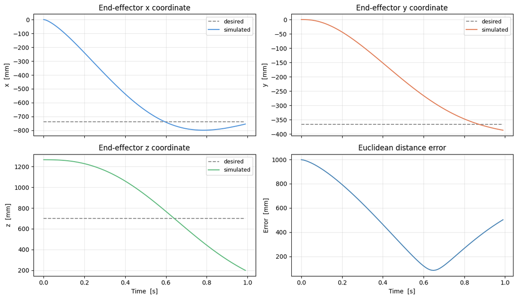

```python
desired_state_func = lambda t: (
    np.array([0.3, 1, 0.5, -0.3, 1, 0.5, 0.1]),  # q_d
    np.zeros(7),                                    # q_dot_d
    np.zeros(7),                                    # q_ddot_d
)

t, q, q_dot = simulate(test_PID, desired_state_func, q_0=np.zeros(7), q_dot_0=np.zeros(7), t_span=(0, 1), dt=0.01, rtol=1e-3, atol=1e-5)

plot_tracking_error(t, q, desired_state_func)

animate_robot(t, q)
```

# Question 3

First, the worst-case inertia configuration is selected. This is when the arm is fully extended horizontally:

$$q^* = [0,\ \pi/2,\ 0,\ 0,\ 0,\ 0,\ 0]$$

## Decentralized PID Joint Controller

### Principle

A decentralized controller treats each joint as an independent SISO system. Each joint $i$ gets its own PID loop, ignoring coupling with other joints. This is computationally cheap and straightforward to implement, but does not compensate for gravity, Coriolis, or inertia coupling between joints.

### Control Law

$$\tau_i = K_p \, e_i + K_i \int e_i \, d\xi - K_d \, \dot{q}_i$$

where $e_i = q_{d,i} - q_i$ is the position error for joint $i$.

### Gain Selection — Critical Damping

To select the gains, each joint $i$ is modelled as a single-DOF mass–damper system driven by its diagonal inertia $B_{ii}(q^*)$ evaluated at the worst-case configuration. Critical damping ($\zeta_i = 1$) is achieved with:

$$K_d = 2\sqrt{K_p \, B_{ii}(q^*)}$$

This makes the effective natural frequency $\omega_{n,i} = \sqrt{K_p / B_{ii}(q^*)}$ depend on the joint inertia, meaning heavier joints converge more slowly for the same $K_p$.

### Anti-Windup

The integral state is clipped to $[-e_{\max},\, +e_{\max}]$ with $e_{\max} = 5$ rad·s, preventing integrator wind-up during large transients.

### Limitations

- **Gravity**: With no feedforward gravity term, the integrator must wind up to compensate for gravity, introducing a transient offset before steady-state is reached.
- **Coupling**: Cross-joint inertia ($B_{ij}$, $i \ne j$) and Coriolis terms are unmodelled; at high speeds or in complex configurations these cause tracking errors the decentralised PID cannot anticipate.
- **Configuration-dependence**: Gains are tuned at $q^*$; far from this configuration $B_{ii}(q)$ may differ significantly, altering the effective damping ratio.

### Implementation

The code below implements the PID controller described above, and validates it by running the model with the controller trying to hold the arm in a stable stretched-out position.

```
End-effector position error:
  Final : 0.02 mm
  Mean  : 10.36 mm
  Max   : 73.04 mm
```

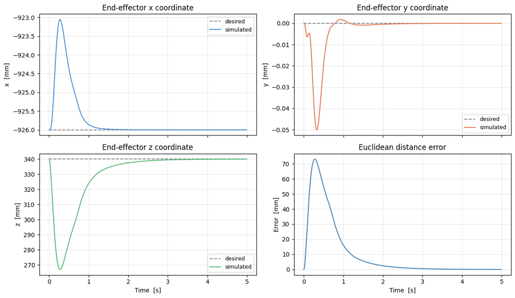

```python
# ── Worst-case inertia configuration ─────────────────────────────────────────
Q_TARGET = np.array([0.0, np.pi/2, 0.0, 0.0, 0.0, 0.0, 0.0])

def desired_state_func(t):
    return Q_TARGET, np.zeros(7), np.zeros(7)

# ── Critically damped gains at worst-case configuration ───────────────────────
B_mid  = B(Q_TARGET)
B_diag = np.diag(B_mid)

Kp_pid = 1000
Kd_pid = 2.0 * np.sqrt(Kp_pid * B_diag)
Ki_pid = 40

TAU_MAX = 500.0

dt        = 0.01
_integral = np.zeros(7)

def PID_func(t, q, q_dot, desired_state_func):
    global _integral
    q_d, _, _  = desired_state_func(t)
    q_desired   = np.asarray(q_d)
    e           = q_desired - q
    _integral   = np.clip(_integral + e * dt, -5.0, 5.0)
    tau         = Kp_pid * e + Ki_pid * _integral - Kd_pid * q_dot
    return np.clip(tau, -TAU_MAX, TAU_MAX)

# ── Simulate ──────────────────────────────────────────────────────────────────
_integral = np.zeros(7)

t, q, q_dot = simulate(
    PID_func, desired_state_func,
    q_0=Q_TARGET, q_dot_0=np.zeros(7),
    t_span=(0, 5.0), dt=dt, rtol=1e-3, atol=1e-5
)

plot_tracking_error(t, q, desired_state_func)
animate_robot(t, q)
```

From the plots it can be observed that gravity causes an initial error as the arm is pulled down, but the I-term soon builds up and recovers the arm to the desired position.

# Question 4

For question 4, we need to implement a centralized inverse dynamics controller for the robot arm. We will implement joint-space computed torque control (CTC).

This controller is based on the exact same equation that we used for defining the model in question 2: $$ \tau = B(q)\ddot{q} + C(q, \dot{q})\dot{q} + g(q) $$

To control the acceleration of the joints directly, taking gravity, inertia and coriolis effects into account, we simply set the torque we give to the motors to be decided by the equation above, by setting: $$ \tau = B(q)\ddot{q}_r + C(q, \dot{q})\dot{q} + g(q) $$ Where $\ddot{q}_r$ is the desired reference acceleration. Inserting this torque expression into the equation above describing the dynamics of the robot arm we get: $$ B(q)\ddot{q}_r + C(q, \dot{q})\dot{q} + g(q) = B(q)\ddot{q} + C(q, \dot{q})\dot{q} + g(q) $$ Which simplifies to: $$\ddot{q}_r = \ddot{q}$$ Assuming that there is no noise or external forces except what is modelled in the dynamics equation, the joints acceleration perfectly matches our desired acceleration!

But still, one problem remains. We could just match the desired acceleration to the acceleration of our desired path, but noise and errors would accumulate and the position of the robot arm would drift away from the desired position. We would have a useless controller. Therefore, we need some clever way to find a desired acceleration that takes the position and velocity into account to lead us to our actual desired state - a feedback loop.

We will implement this feedback loop using the equation: $$\ddot{q}_r = \ddot{q}_d + K_p \, e + K_d \, \dot{e}$$

Where the $K$'s are gain matrices we need to tune, $e$ is the position error and $\dot{e}$ is the velocity error. The errors are defined as:

$$e = q_d - q$$

$$\dot{e} = \dot{q}_d - \dot{q}$$

Here is the code implementation of the $\ddot{q}_r$ function:

```python
def q_ddot_r(t, q, q_dot, desired_state_func, Kp, Kd):
    """Reference acceleration for computed torque control.

    Returns q_ddot_r = q_ddot_d + Kp @ (q_d - q) + Kd @ (q_dot_d - q_dot)
    """
    q_d, q_dot_d, q_ddot_d = desired_state_func(t)
    e     = np.asarray(q_d,     float) - q
    e_dot = np.asarray(q_dot_d, float) - q_dot
    return np.asarray(q_ddot_d, float) + Kp @ e + Kd @ e_dot
```

If we insert the feedback loop equation to the simplified dynamics equation, we get: $$\ddot{q} = \ddot{q}_d + K_p \, e + K_d \, \dot{e}$$ Which can be rewritten to: $$K_p \, e + K_d \, \dot{e} + \ddot{e} = 0$$ We see that the error dynamics of the robot arm now act as a standard mass-damper system, where we can choose the coeficcients ourself to get the desired behaviour.

Normally, we chose $\zeta =1$ by setting $K_p = \omega_n^2$ and $K_d = 2 \omega_n$. However, we still have the omega parameter to play with. The higher we set this parameter, the faster the robot arm will converge to the desired position. In our theoretical model, we would get the best possible result by increasing $\omega_n$ as much as possible. However, if we increase it too much for a real application the actuators will not be able to provide the required torque, and the robot arm becomes more sensitive to inaccuracies in the dynamical model. We chose to set $\omega_n = 12$. This gives the following values for the tuning constants:

$$K_p = \omega_n^2 \mathbf{I} = 144\mathbf{I}, \quad K_d = 2\omega_n \mathbf{I} = 24\mathbf{I}$$ Below is the code implementation of this, the constants are implemented as diagonal matrixes with the tuning constant along the diagonal:

```python
Kp = 144 * np.eye(7)   # ω_n = 12 rad/s
Kd =  24 * np.eye(7)   # critically damped: Kd = 2ω_n
```

### Full control function implementation

With all the prequisites in place, we can implement the full function for the CTC algorithm:

```python
def computed_torque_control(t, q, q_dot, desired_state_func):
    q_r = q_ddot_r(t, q, q_dot, desired_state_func, Kp, Kd)
    return B(q) @ q_r + C_vector(q, q_dot) + g(q)
```

### Validation

To validate that the CTC algorithm works as expected, we test it on a simple path:

```
End-effector position error:
  Final : 0.00 mm
  Mean  : 58.17 mm
  Max   : 998.32 mm
```

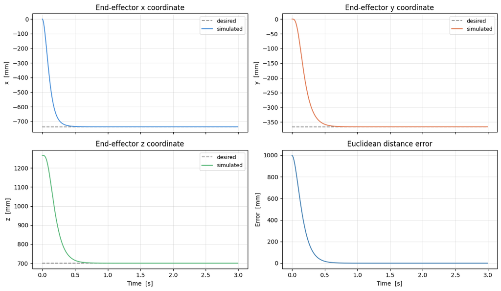

```python
desired_state_func = lambda t: (
    np.array([0.3, 1.0, 0.5, -0.3, 1.0, 0.5, 0.1]),
    np.zeros(7),
    np.zeros(7),
)

t, q, q_dot = simulate(computed_torque_control, desired_state_func, q_0=np.zeros(7), q_dot_0=np.zeros(7), t_span=(0, 3))
plot_tracking_error(t, q, desired_state_func)
animate_robot(t, q)
```

# Question 5

## Comparison: Decentralized PID vs Computed Torque Control

In this question, the PID and the CTC algorithms are compared on a complicated end-effector path.

### End effector path

The first step is to define an end effector path in the task space that will be used to compare the two controllers. This path is constructed by specifying points that the end-effector should travel through, then using linear interpolation to interpolate between the points. Linear interpolation is used instead of a spline, as it preserves the straightness of the segments for rectangular movements. This also creates acceleration spikes at corners, which will be interesting to see how the different controllers handle.

The path includes the robot's end effector first moving in a square pattern in two planes, then moving linearly up and down, then in a circle in the XZ-plane. The full motion takes about 8.2 seconds.

### End effector orientation

In addition to the position path, the orientation of the end effector is specified for each segment:

```python
# ═══════════════════════════════════════════════════════════════════════════════
# 1. CARTESIAN PATH DEFINITION
#    XY square → XZ square → linear up-down → XZ circle  (≈ 8.2 s)
#    Path uses linear interpolation: constant velocity on each segment.
# ═══════════════════════════════════════════════════════════════════════════════

Q_PATH_START = np.array([-np.pi/4, -np.pi/6, 0.0, np.pi*(4/6), 0.0, -np.pi/4, 0.0])
T_ee    = n_T_n_from_DH_table(DH(Q_PATH_START), 0, 7)
p_c     = T_ee[:3, 3].copy()
R_fixed = T_ee[:3, :3].copy()

r   = 0.2  # square half-side and circle radius  [m]
r_z = -0.30   # vertical amplitude for up-down      [m]
print(f"EE centre: x={p_c[0]:.3f}  y={p_c[1]:.3f}  z={p_c[2]:.3f} m")

t_pre = np.linspace(0, 5.8, 14)   # 14 waypoints for pre-circle path
p_pre = np.vstack([
    p_c,
    p_c + [ 0, -r,   0],
    p_c + [ r,  -r,   0],
    p_c + [r,  0,   0],
    p_c,
    p_c,
    p_c + [ r,  0,  0],
    p_c + [ r,  0,   -r],
    p_c + [0,  0,   -r],
    p_c,
    p_c,
    p_c + [0,  0,   r_z],
    p_c,
    p_c,
])

theta_c  = np.linspace(0, 2 * np.pi, 360)
t_circle = np.linspace(5.8, 8.2, 360)
p_circle = np.column_stack([
    p_c[0] + r * np.cos(theta_c),
    np.full(360, p_c[1]),
    p_c[2] + r * np.sin(theta_c),
])

t_wpts = np.concatenate([t_pre, t_circle])
p_wpts = np.vstack([p_pre, p_circle])
T_PATH = t_wpts[-1]   # 8.2 s

# ── Linear interpolation for position ────────────────────────────────────────
_p_interp = interp1d(t_wpts, p_wpts, axis=0, kind='linear')

# ── Piecewise-constant velocity (finite difference of consecutive waypoints) ──
_v_seg = np.diff(p_wpts, axis=0) / np.diff(t_wpts)[:, None]  # (N-1, 3)
# At endpoint, velocity is zero; use 'previous' step interpolation
_v_wpts = np.vstack([_v_seg, np.zeros((1, 3))])
_v_interp = interp1d(t_wpts, _v_wpts, axis=0, kind='previous',
                     bounds_error=False, fill_value=(_v_seg[0], np.zeros(3)))

def p_path(t):
    return _p_interp(float(np.clip(t, 0, T_PATH)))

def p_dot_path(t):
    return _v_interp(float(np.clip(t, 0, T_PATH)))
```

```
EE centre: x=0.260  y=-0.260  z=0.218 m
```

```python
# ═══════════════════════════════════════════════════════════════════════════════
# 1b. END-EFFECTOR ORIENTATION PATH
#     XY square : EE z-axis ⊥ XY plane  →  z = [0, 0, -1]  (pointing down)
#     XZ square : EE z-axis ⊥ XZ plane  →  z = [0, -1,  0]
#     Circle    : fixed — EE ⊥ XZ plane  →  z = [0, -1,  0]  (same as XZ square)
#
#     0.4 s SLERP transition at t = 1.6  (XY → XZ)
# ═══════════════════════════════════════════════════════════════════════════════
from scipy.spatial.transform import Rotation, Slerp

def _make_R_from_z(z_hat):
    z = np.asarray(z_hat, float); z = z / np.linalg.norm(z)
    up = np.array([0., 1., 0.]) if abs(z[1]) < 0.9 else np.array([1., 0., 0.])
    x  = np.cross(up, z);  x = x / np.linalg.norm(x)
    y  = np.cross(z, x)
    return np.column_stack([x, y, z])

R_XY     = _make_R_from_z([0.,  0., -1.])   # perpendicular to XY (down)
R_XZ     = _make_R_from_z([0., -1.,  0.])   # perpendicular to XZ
R_circle = R_XZ                              # circle is in XZ plane → same orientation

_SEG_XY_END   = 1.6
_TRANS        = 0.4

def _slerp_pair(R_a, R_b, alpha):
    rots = Rotation.from_matrix(np.stack([R_a, R_b]))
    return Slerp([0., 1.], rots)(float(np.clip(alpha, 0., 1.))).as_matrix()

def R_path(t):
    t = float(np.clip(t, 0.0, T_PATH))

    # XZ square, gap, and circle all share the same orientation
    if t >= _SEG_XY_END + _TRANS:
        return R_XZ

    # Transition XY → XZ
    if t >= _SEG_XY_END:
        return _slerp_pair(R_XY, R_XZ, (t - _SEG_XY_END) / _TRANS)

    return R_XY

def omega_path(t):
    return np.zeros(3)
```

### From task-space end effector path to joint-space trajectory

In order to simulate the controllers, we need to convert this task-space end effector trajectory into a joint-space trajectory. This is done using the CLIK algorithm that was implemented in the kinematics project earlier in the semester. The acceleration of the joint is also calculated by differentiating the velocity of the joints.

```python
# ═══════════════════════════════════════════════════════════════════════════════
# 2. JOINT TRAJECTORY VIA CLIK
# ═══════════════════════════════════════════════════════════════════════════════

dt_path = 0.01
t_arr   = np.arange(0.0, T_PATH + dt_path / 2, dt_path)
N_steps = len(t_arr)

K_P_c = 15.0
K_O_c = 10.0
K_N_c = 0.05

q_traj    = np.zeros((N_steps, 7))
qdot_traj = np.zeros((N_steps, 7))
q_curr    = Q_PATH_START.copy()

print("Generating CLIK trajectory...")
for i, t in enumerate(tqdm(t_arr, desc='CLIK')):
    p_d    = p_path(t)
    pd_dot = p_dot_path(t)

    T_e  = n_T_n_from_DH_table(DH(q_curr), 0, 7)
    p_e  = T_e[:3, 3]
    R_e  = T_e[:3, :3]

    e_P = p_d - p_e

    R_err = R_path(t) @ R_e.T
    angle = np.arccos(np.clip((np.trace(R_err) - 1) / 2, -1.0, 1.0))
    if abs(angle) < 1e-9:
        e_O = np.zeros(3)
    else:
        ax  = np.array([R_err[2,1]-R_err[1,2],
                        R_err[0,2]-R_err[2,0],
                        R_err[1,0]-R_err[0,1]]) / (2 * np.sin(angle))
        e_O = ax * angle

    v_ref  = np.concatenate([pd_dot + K_P_c * e_P, omega_path(t) + K_O_c * e_O])
    J_q    = geometric_jacobian_from_DH_table(DH(q_curr))
    J_pinv = np.linalg.pinv(J_q)
    N_proj = np.eye(7) - J_pinv @ J_q
    qd     = J_pinv @ v_ref + N_proj @ (-K_N_c * q_curr)

    q_traj[i]    = q_curr
    qdot_traj[i] = qd
    q_curr       = q_curr + qd * dt_path

qddot_traj = np.gradient(qdot_traj, dt_path, axis=0)

_q_ip   = interp1d(t_arr, q_traj,     axis=0, kind='linear', bounds_error=False,
                   fill_value=(q_traj[0],    q_traj[-1]))
_qd_ip  = interp1d(t_arr, qdot_traj,  axis=0, kind='linear', bounds_error=False,
                   fill_value=(qdot_traj[0], qdot_traj[-1]))
_qdd_ip = interp1d(t_arr, qddot_traj, axis=0, kind='linear', bounds_error=False,
                   fill_value=(qddot_traj[0], qddot_traj[-1]))

def desired_state_func_q5(t):
    return _q_ip(t), _qd_ip(t), _qdd_ip(t)
```

```
Generating CLIK trajectory...
```

### Verifying Path

To verify that the CLIK path is valid, a 3d-animation is made of the robot arm perfectly following the path. If we see any difference between the desired path and the CLIK EE, that there is a singularity or out of bounds issue.

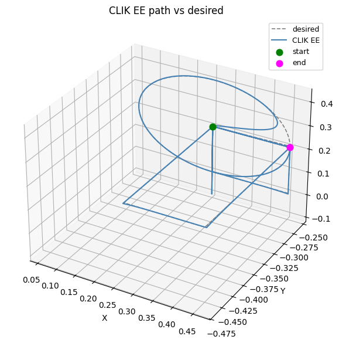

```
CLIK position error — mean: 2.14 mm   max: 200.02 mm
```

```python
# EE position from CLIK joint trajectory
p_clik = np.array([n_T_n_from_DH_table(DH(q_traj[i]), 0, 7)[:3, 3]
                   for i in range(len(t_arr))])
p_desired = np.array([p_path(t) for t in t_arr])

# 3-D path check: desired vs CLIK
fig = plt.figure(figsize=(7, 6))
ax  = fig.add_subplot(111, projection='3d')
ax.plot(*p_desired.T, '--', color='gray',      lw=1.2, label='desired')
ax.plot(*p_clik.T,          color='steelblue', lw=1.5, label='CLIK EE')
ax.scatter(*p_clik[0],  color='green',   s=60, zorder=5, label='start')
ax.scatter(*p_clik[-1], color='magenta', s=60, zorder=5, label='end')
ax.set_xlabel('X'); ax.set_ylabel('Y'); ax.set_zlabel('Z')
ax.set_title('CLIK EE path vs desired')
ax.legend(fontsize=9)
plt.tight_layout()
plt.show()

err = np.linalg.norm(p_clik - p_desired, axis=1)
print(f"CLIK position error — mean: {err.mean()*1e3:.2f} mm   max: {err.max()*1e3:.2f} mm")

animate_robot(t_arr, q_traj)
```

### Running the simulation

The simulate function implemented earlier is called to simulate how the two controllers act, giving the joint-soace paths as input.

```python
# ═══════════════════════════════════════════════════════════════════════════════
# 3. SIMULATE BOTH CONTROLLERS
# ═══════════════════════════════════════════════════════════════════════════════

_integral = np.zeros(7)
t_pid, q_pid, _ = simulate(
    PID_func, desired_state_func_q5,
    q_0=Q_PATH_START.copy(), q_dot_0=np.zeros(7),
    t_span=(0, T_PATH), dt=dt, rtol=1e-3, atol=1e-5
)

t_ctc, q_ctc, _ = simulate(
    computed_torque_control, desired_state_func_q5,
    q_0=Q_PATH_START.copy(), q_dot_0=np.zeros(7),
    t_span=(0, T_PATH), dt=dt, rtol=1e-3, atol=1e-5
)
```

### Plots

The results from both controllers are plotted in a 2d-plot showing their respective x, y and z positions along with the desired positions, and an error plot showing the euclidian distance between the desired end-effector position and the position the controller generates.

The rotation of the end-effector is not evaluated in the plots, as it is easier to get an intuitive understanding for the end effector coordinate plots, and these plots are sufficient to compare the controllers.

```
PID — final: 73.41 mm   mean: 56.18 mm
CTC — final: 0.70 mm   mean: 4.63 mm
```

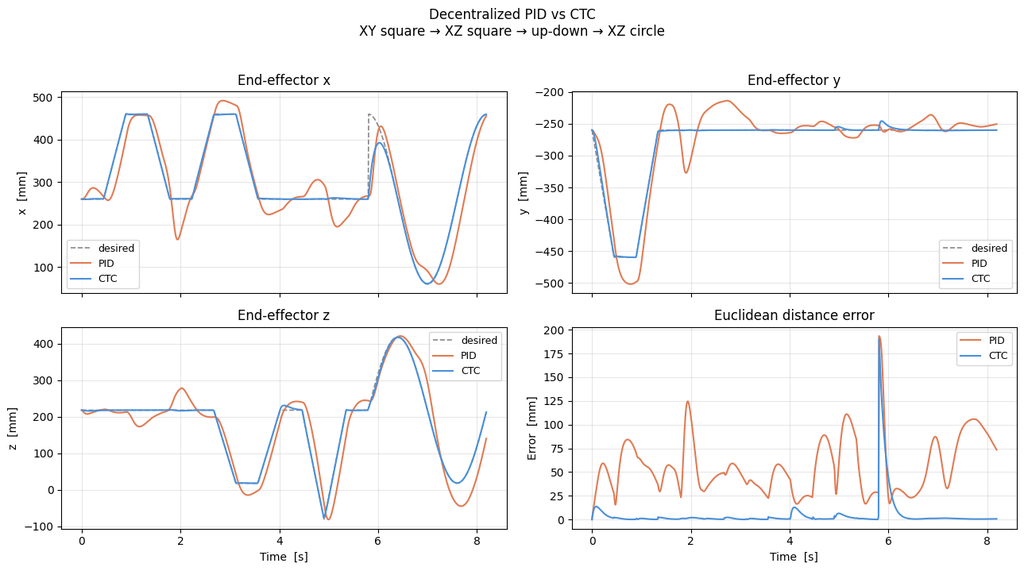

```
=== PID Controller — 3D ===
```

```
=== Computed Torque Control — 3D ===
```

```python
# ═══════════════════════════════════════════════════════════════════════════════
# 4. PLOTS
# ═══════════════════════════════════════════════════════════════════════════════

n = q_pid.shape[1]
p_pid = np.array([n_T_n_from_DH_table(DH(q_pid[i]), 0, n)[:3, 3] for i in range(len(t_pid))])
p_ctc = np.array([n_T_n_from_DH_table(DH(q_ctc[i]), 0, n)[:3, 3] for i in range(len(t_ctc))])
p_des = np.array([p_path(ti) for ti in t_pid])

err_pid = np.linalg.norm(p_pid - p_des, axis=1)
err_ctc = np.linalg.norm(p_ctc - p_des, axis=1)

print(f"PID — final: {err_pid[-1]*1e3:.2f} mm   mean: {err_pid.mean()*1e3:.2f} mm")
print(f"CTC — final: {err_ctc[-1]*1e3:.2f} mm   mean: {err_ctc.mean()*1e3:.2f} mm")

fig, axes = plt.subplots(2, 2, figsize=(13, 7), sharex=True)
for k, (ax, coord) in enumerate(zip(axes.flat, ['x', 'y', 'z'])):
    ax.plot(t_pid, p_des[:, k] * 1e3, '--', color='#888888', lw=1.2, label='desired')
    ax.plot(t_pid, p_pid[:, k] * 1e3,       color='#e07b54', lw=1.5, label='PID')
    ax.plot(t_ctc, p_ctc[:, k] * 1e3,       color='#4a90d9', lw=1.5, label='CTC')
    ax.set_ylabel(f'{coord}  [mm]')
    ax.set_title(f'End-effector {coord}')
    ax.legend(fontsize=9)
    ax.grid(alpha=0.3)
ax_err = axes[1, 1]
ax_err.plot(t_pid, err_pid * 1e3, color='#e07b54', lw=1.5, label='PID')
ax_err.plot(t_ctc, err_ctc * 1e3, color='#4a90d9', lw=1.5, label='CTC')
ax_err.set_ylabel('Error  [mm]')
ax_err.set_title('Euclidean distance error')
ax_err.legend(fontsize=9)
ax_err.grid(alpha=0.3)
for ax in axes[1]:
    ax.set_xlabel('Time  [s]')
plt.suptitle('Decentralized PID vs CTC\n'
             'XY square → XZ square → up-down → XZ circle', y=1.02)
plt.tight_layout()
plt.show()

print("=== PID Controller — 3D ===")
animate_robot(t_pid, q_pid)

print("=== Computed Torque Control — 3D ===")
animate_robot(t_ctc, q_ctc)
```

### Analyzing results

From the 2d-plots we can clearly see that the CTC controller performs better than the PID controller.

The CTC controller is almost directly on the desired coordinates most of the time, with only small deviations caused by insufficient torque in the actuators to provide the required acelleration at sharp corners in the path. This is a hardware limitation, and would have to be solved by designing a path with continous velocity, for example using splines.

The PID controller lags behind the desired coordinate when it changes, and overshoots the desired position due to buildup of the I-term.

We can also observe that it deviates from the desired y-coordinate in the second half of the trajectory, even though the desired trajectory just has a constant y-position for this timespan. This is because it is a decentralized controller. All joints act independently, and they converge with different speeds, leading to deviations from the desired coordinate even though the desired coordinate does not move.

The spike in the error of both controllers at just before 6 seconds is caused by an irregularity in the path, demanding an instant change of the x-coordinate of the end effector. We can see that both controllers are able to recover quickly from the error introduced by this irregularity.

PID — final: 73.41 mm mean: 56.18 mm

CTC — final: 0.70 mm mean: 4.63 mm

It is worth noting that the simulation only simulates ideal contitions with no noise or friction. Adding noise and friction to the model simulation would cause both controllers to perform worse.